# Estudo de caso - Cyclistic

## Estudo de casos - Cyclistic - Google Certificado - Analista de Dados

O projeto final de Data Analytics do Google é uma etapa crucial para concluir o curso de análise de dados do Google e obter a certificação em análise de dados. Este estudo de caso visa aplicar e demonstrar o conhecimento adquirido ao longo do curso, utilizando diversas ferramentas como Google Sheets, R, SQL e Tableau.

O projeto final é uma oportunidade de mostrar sua habilidade em aplicar técnicas de análise de dados, desde a coleta e limpeza dos dados até a visualização e interpretação dos resultados. Ao concluir esse estudo de caso, o aluno estará preparado para receber a certificação em análise de dados do Google e poderá demonstrar sua expertise na área de análise de dados para futuros empregadores ou clientes.

Através deste projeto, o estudante terá a oportunidade de consolidar seus conhecimentos e habilidades em análise de dados, bem como aprofundar sua compreensão sobre o e-commerce. Ao finalizar o estudo de caso, o aluno estará apto a enfrentar desafios reais de análise de dados e contribuir significativamente para o sucesso de empresas e organizações.

## Cenário

Você é um analista de dados júnior que trabalha na equipe de analistas de marketing da Cyclistic, uma empresa de compartilhamento de bicicletas em Chicago. O diretor de marketing acredita que o sucesso futuro da empresa depende da maximização do número de planos anuais contratados. Portanto, sua equipe quer entender como os ciclistas casuais e os membros anuais usam as bicicletas da Cyclistic de forma diferente. A partir desses insights, sua equipe criará uma nova estratégia de marketing para converter passageiros casuais em membros anuais. Mas, primeiro, os executivos da Cyclistic devem aprovar suas recomendações que, portanto, devem ser apoiadas com insights de dados convincentes e visualizações de dados profissionais.

## Personagens e equipes

● Cyclistic: Um programa de compartilhamento de bicicletas que conta com mais de 5.800 bicicletas e 600 estações de compartilhamento. A Cyclistic se diferencia por também oferecer bicicletas reclináveis, triciclos manuais e bicicletas de carga, tornando o compartilhamento de bicicletas mais inclusivo para pessoas com deficiência e ciclistas que não podem usar uma bicicleta padrão de duas rodas. A maioria dos ciclistas opta por bicicletas tradicionais; cerca de 8% dos motociclistas usam as opções assistivas. Os usuários da Cyclistic são mais propensos a pedalar por lazer, mas cerca de 30% utilizam as bicicletas para se deslocarem ao trabalho diariamente.

● Lily Moreno: Diretora de marketing e sua gerente. Lily é responsável pelo desenvolvimento de campanhas e iniciativas de promoção do programa de compartilhamento de bicicletas. As campanhas podem incluir e-mail, mídias sociais e outros canais.

● Equipe de análise de marketing da Cyclistic: Uma equipe de analistas de dados responsáveis por coletar, analisar e relatar dados que ajudam a orientar a estratégia de marketing da Cyclistic. Você se juntou a essa equipe há seis meses e tem estado ocupado aprendendo sobre a missão e os objetivos de negócios da Cyclistic – e como você, como analista de dados júnior, também pode ajudar a Cyclistic a alcançá-los.

● Equipe executiva da Cyclistic: A equipe executiva notoriamente detalhista decidirá se aprova o programa de marketing recomendado.

## Perguntas

Três perguntas nortearão o futuro programa de marketing: 1. Como os membros anuais e os ciclistas casuais usam as bicicletas da Cyclistic de forma diferente? 2. Por que os passageiros casuais iriam querer adquirir planos anuais da Cyclistic? 3. Como a Cyclistic pode usar a mídia digital para influenciar os passageiros casuais a se tornarem membros?

Abaixo segue análise do conjunto de dados em questão feita em R.

## Carregando os Dados e Bibliotecas

### Carregando as bibliotecas:

```r
library("dplyr")
```

```r
library("ggplot2")
library("tidyverse")
library("lubridate")
library("skimr")
library("e1071")
library("ggthemes")
library("reshape2")
library("kableExtra")
library("geosphere")
library("scales")
library("knitr")
library("bsplus")
library("writexl")
```

### Carregando os 12 arquivos .CSV’s:

```r
c01 <- read.csv("C:/Users/welin/Desktop/GOOGLE/Estudos de caso/1/202201.csv")
c02 <- read.csv("C:/Users/welin/Desktop/GOOGLE/Estudos de caso/1/202202.csv")
c03 <- read.csv("C:/Users/welin/Desktop/GOOGLE/Estudos de caso/1/202203.csv")
c04 <- read.csv("C:/Users/welin/Desktop/GOOGLE/Estudos de caso/1/202204.csv")
c05 <- read.csv("C:/Users/welin/Desktop/GOOGLE/Estudos de caso/1/202205.csv")
c06 <- read.csv("C:/Users/welin/Desktop/GOOGLE/Estudos de caso/1/202206.csv")
c07 <- read.csv("C:/Users/welin/Desktop/GOOGLE/Estudos de caso/1/202207.csv")
c08 <- read.csv("C:/Users/welin/Desktop/GOOGLE/Estudos de caso/1/202208.csv")
c09 <- read.csv("C:/Users/welin/Desktop/GOOGLE/Estudos de caso/1/202209.csv")
c10 <- read.csv("C:/Users/welin/Desktop/GOOGLE/Estudos de caso/1/202210.csv")
c11 <- read.csv("C:/Users/welin/Desktop/GOOGLE/Estudos de caso/1/202211.csv")
c12 <- read.csv("C:/Users/welin/Desktop/GOOGLE/Estudos de caso/1/202212.csv")
```

### Analisando os tipos de dados:

```r
str(c01)
```

```
## 'data.frame':    103770 obs. of  13 variables:
##  $ ride_id           : chr  "C2F7DD78E82EC875" "A6CF8980A652D272" "BD0F91DFF741C66D" "CBB80ED419105406" ...
##  $ rideable_type     : chr  "electric_bike" "electric_bike" "classic_bike" "classic_bike" ...
##  $ started_at        : chr  "2022-01-13 11:59:47" "2022-01-10 08:41:56" "2022-01-25 04:53:40" "2022-01-04 00:18:04" ...
##  $ ended_at          : chr  "2022-01-13 12:02:44" "2022-01-10 08:46:17" "2022-01-25 04:58:01" "2022-01-04 00:33:00" ...
##  $ start_station_name: chr  "Glenwood Ave & Touhy Ave" "Glenwood Ave & Touhy Ave" "Sheffield Ave & Fullerton Ave" "Clark St & Bryn Mawr Ave" ...
##  $ start_station_id  : chr  "525" "525" "TA1306000016" "KA1504000151" ...
##  $ end_station_name  : chr  "Clark St & Touhy Ave" "Clark St & Touhy Ave" "Greenview Ave & Fullerton Ave" "Paulina St & Montrose Ave" ...
##  $ end_station_id    : chr  "RP-007" "RP-007" "TA1307000001" "TA1309000021" ...
##  $ start_lat         : num  42 42 41.9 42 41.9 ...
##  $ start_lng         : num  -87.7 -87.7 -87.7 -87.7 -87.6 ...
##  $ end_lat           : num  42 42 41.9 42 41.9 ...
##  $ end_lng           : num  -87.7 -87.7 -87.7 -87.7 -87.6 ...
##  $ member_casual     : chr  "casual" "casual" "member" "casual" ...
```

```r
str(c04)
```

```
## 'data.frame':    371249 obs. of  13 variables:
##  $ ride_id           : chr  "3564070EEFD12711" "0B820C7FCF22F489" "89EEEE32293F07FF" "84D4751AEB31888D" ...
##  $ rideable_type     : chr  "electric_bike" "classic_bike" "classic_bike" "classic_bike" ...
##  $ started_at        : chr  "2022-04-06 17:42:48" "2022-04-24 19:23:07" "2022-04-20 19:29:08" "2022-04-22 21:14:06" ...
##  $ ended_at          : chr  "2022-04-06 17:54:36" "2022-04-24 19:43:17" "2022-04-20 19:35:16" "2022-04-22 21:23:29" ...
##  $ start_station_name: chr  "Paulina St & Howard St" "Wentworth Ave & Cermak Rd" "Halsted St & Polk St" "Wentworth Ave & Cermak Rd" ...
##  $ start_station_id  : chr  "515" "13075" "TA1307000121" "13075" ...
##  $ end_station_name  : chr  "University Library (NU)" "Green St & Madison St" "Green St & Madison St" "Delano Ct & Roosevelt Rd" ...
##  $ end_station_id    : chr  "605" "TA1307000120" "TA1307000120" "KA1706005007" ...
##  $ start_lat         : num  42 41.9 41.9 41.9 41.9 ...
##  $ start_lng         : num  -87.7 -87.6 -87.6 -87.6 -87.6 ...
##  $ end_lat           : num  42.1 41.9 41.9 41.9 41.9 ...
##  $ end_lng           : num  -87.7 -87.6 -87.6 -87.6 -87.6 ...
##  $ member_casual     : chr  "member" "member" "member" "casual" ...
```

```r
str(c08)
```

```
## 'data.frame':    785932 obs. of  13 variables:
##  $ ride_id           : chr  "550CF7EFEAE0C618" "DAD198F405F9C5F5" "E6F2BC47B65CB7FD" "F597830181C2E13C" ...
##  $ rideable_type     : chr  "electric_bike" "electric_bike" "electric_bike" "electric_bike" ...
##  $ started_at        : chr  "2022-08-07 21:34:15" "2022-08-08 14:39:21" "2022-08-08 15:29:50" "2022-08-08 02:43:50" ...
##  $ ended_at          : chr  "2022-08-07 21:41:46" "2022-08-08 14:53:23" "2022-08-08 15:40:34" "2022-08-08 02:58:53" ...
##  $ start_station_name: chr  "" "" "" "" ...
##  $ start_station_id  : chr  "" "" "" "" ...
##  $ end_station_name  : chr  "" "" "" "" ...
##  $ end_station_id    : chr  "" "" "" "" ...
##  $ start_lat         : num  41.9 41.9 42 41.9 41.9 ...
##  $ start_lng         : num  -87.7 -87.6 -87.7 -87.7 -87.7 ...
##  $ end_lat           : num  41.9 41.9 42 42 41.8 ...
##  $ end_lng           : num  -87.7 -87.6 -87.7 -87.7 -87.7 ...
##  $ member_casual     : chr  "casual" "casual" "casual" "casual" ...
```

```r
str(c12)
```

```
## 'data.frame':    181806 obs. of  13 variables:
##  $ ride_id           : chr  "65DBD2F447EC51C2" "0C201AA7EA0EA1AD" "E0B148CCB358A49D" "54C5775D2B7C9188" ...
##  $ rideable_type     : chr  "electric_bike" "classic_bike" "electric_bike" "classic_bike" ...
##  $ started_at        : chr  "2022-12-05 10:47:18" "2022-12-18 06:42:33" "2022-12-13 08:47:45" "2022-12-13 18:50:47" ...
##  $ ended_at          : chr  "2022-12-05 10:56:34" "2022-12-18 07:08:44" "2022-12-13 08:59:51" "2022-12-13 19:19:48" ...
##  $ start_station_name: chr  "Clifton Ave & Armitage Ave" "Broadway & Belmont Ave" "Sangamon St & Lake St" "Shields Ave & 31st St" ...
##  $ start_station_id  : chr  "TA1307000163" "13277" "TA1306000015" "KA1503000038" ...
##  $ end_station_name  : chr  "Sedgwick St & Webster Ave" "Sedgwick St & Webster Ave" "St. Clair St & Erie St" "Damen Ave & Madison St" ...
##  $ end_station_id    : chr  "13191" "13191" "13016" "13134" ...
##  $ start_lat         : num  41.9 41.9 41.9 41.8 41.9 ...
##  $ start_lng         : num  -87.7 -87.6 -87.7 -87.6 -87.7 ...
##  $ end_lat           : num  41.9 41.9 41.9 41.9 41.9 ...
##  $ end_lng           : num  -87.6 -87.6 -87.6 -87.7 -87.7 ...
##  $ member_casual     : chr  "member" "casual" "member" "member" ...
```

## Limpeza e Tratamento dos Dados para analise

### Combinando os 12 arquivos .CSV’s em um único dataframe. Que será chamado de “cyclist2022”:

```r
cyclist2022 <- rbind(c01, c02, c03, c04, c05, c06, c07, c08, c09, c10, c11, c12)
```

### Abrindo apenas as 6 primeiras linhas:

```r
head(cyclist2022)
```

```
##            ride_id rideable_type          started_at            ended_at
## 1 C2F7DD78E82EC875 electric_bike 2022-01-13 11:59:47 2022-01-13 12:02:44
## 2 A6CF8980A652D272 electric_bike 2022-01-10 08:41:56 2022-01-10 08:46:17
## 3 BD0F91DFF741C66D  classic_bike 2022-01-25 04:53:40 2022-01-25 04:58:01
## 4 CBB80ED419105406  classic_bike 2022-01-04 00:18:04 2022-01-04 00:33:00
## 5 DDC963BFDDA51EEA  classic_bike 2022-01-20 01:31:10 2022-01-20 01:37:12
## 6 A39C6F6CC0586C0B  classic_bike 2022-01-11 18:48:09 2022-01-11 18:51:31
##              start_station_name start_station_id              end_station_name
## 1      Glenwood Ave & Touhy Ave              525          Clark St & Touhy Ave
## 2      Glenwood Ave & Touhy Ave              525          Clark St & Touhy Ave
## 3 Sheffield Ave & Fullerton Ave     TA1306000016 Greenview Ave & Fullerton Ave
## 4      Clark St & Bryn Mawr Ave     KA1504000151     Paulina St & Montrose Ave
## 5   Michigan Ave & Jackson Blvd     TA1309000002        State St & Randolph St
## 6         Wood St & Chicago Ave              637       Honore St & Division St
##   end_station_id start_lat start_lng  end_lat   end_lng member_casual
## 1         RP-007  42.01280 -87.66591 42.01256 -87.67437        casual
## 2         RP-007  42.01276 -87.66597 42.01256 -87.67437        casual
## 3   TA1307000001  41.92560 -87.65371 41.92533 -87.66580        member
## 4   TA1309000021  41.98359 -87.66915 41.96151 -87.67139        casual
## 5   TA1305000029  41.87785 -87.62408 41.88462 -87.62783        member
## 6   TA1305000034  41.89563 -87.67207 41.90312 -87.67394        member
```

### Identificando os nomes das colunas e numero de linhas antes da limpeza e tratamento:

```r
colnames(cyclist2022)
```

```
##  [1] "ride_id"            "rideable_type"      "started_at"
##  [4] "ended_at"           "start_station_name" "start_station_id"
##  [7] "end_station_name"   "end_station_id"     "start_lat"
## [10] "start_lng"          "end_lat"            "end_lng"
## [13] "member_casual"
```

```r
numero_de_linhas1 <- nrow(cyclist2022)
print(numero_de_linhas1)
```

```
## [1] 5667717
```

### Apagando linhas das colunas “start_station_name” e “end_station_name” com valores ausentes e criando o dataset “cyclist2022v1” :

```r
cyclist2022v1 <- subset(cyclist2022, nchar(start_station_name) > 0 & nchar(end_station_name) > 0)
```

### Apagando colunas que não serão utilizadas:

```r
cyclist2022v1 <- subset(cyclist2022v1, select = -c(ride_id, start_station_id, end_station_id))
```

### Criando a coluna “data” a partir da coluna “started_at”:

```r
cyclist2022v1 <- cyclist2022v1 %>% mutate(data = as.Date(started_at))
head(cyclist2022v1$data)
```

```
## [1] "2022-01-13" "2022-01-10" "2022-01-25" "2022-01-04" "2022-01-20"
## [6] "2022-01-11"
```

### Criando a coluna “dia_semana” a partir da coluna “data”, recém criada:

```r
cyclist2022v1 <- cyclist2022v1 %>% mutate(dia_semana = weekdays(ymd(data)))
head(cyclist2022v1$dia_semana)
```

```
## [1] "quinta-feira"  "segunda-feira" "terça-feira"   "terça-feira"
## [5] "quinta-feira"  "terça-feira"
```

### Criando a coluna “mes” a partir da coluna “data”:

```r
cyclist2022v1$mes <- month(cyclist2022v1$data, label = TRUE)
head(cyclist2022v1$mes)
```

```
## [1] jan jan jan jan jan jan
## 12 Levels: jan < fev < mar < abr < mai < jun < jul < ago < set < ... < dez
```

### Criando as coluna das estações do ano “estacao” a partir da coluna “mes”:

```r
cyclist2022v1 <- cyclist2022v1 %>%
  mutate(estacao = case_when(
    mes %in% c("jun", "jul", "ago") ~ "Verão",
    mes %in% c("set", "out", "nov") ~ "Outono",
    mes %in% c("dez", "jan", "fev") ~ "Inverno",
    mes %in% c("mar", "abr", "mai") ~ "Primavera",
    TRUE ~ NA_character_
  ))
head(cyclist2022v1$estacao)
```

```
## [1] "Inverno" "Inverno" "Inverno" "Inverno" "Inverno" "Inverno"
```

### Criando a coluna chamada “hora_inicio” a partir da coluna “started_at”:

```r
cyclist2022v1 <- cyclist2022v1 %>% mutate(hora_inicio = format(as.POSIXct(started_at), format = "%H:%M:%S"))
head(cyclist2022v1$hora_inicio)
```

```
## [1] "11:59:47" "08:41:56" "04:53:40" "00:18:04" "01:31:10" "18:48:09"
```

### Criando uma nova coluna chamada “hora_fim” a partir da coluna “ended_at”:

```r
cyclist2022v1 <- cyclist2022v1 %>% mutate(hora_fim = format(as.POSIXct(ended_at), format = "%H:%M:%S"))
head(cyclist2022v1$hora_fim)
```

```
## [1] "12:02:44" "08:46:17" "04:58:01" "00:33:00" "01:37:12" "18:51:31"
```

### Criando a coluna chamada “tempo_total”:

```r
cyclist2022v1 <- cyclist2022v1 %>%
  mutate(tempo_total = as.character(as.POSIXct(hora_fim, format = "%H:%M:%S") -
                                          as.POSIXct(hora_inicio, format = "%H:%M:%S")))
head(cyclist2022v1$tempo_total)
```

```
## [1] "177" "261" "261" "896" "362" "202"
```

### Mudando o tipo de “tempo_total” para numérico:

```r
cyclist2022v1$tempo_total <- as.numeric(cyclist2022v1$tempo_total)
str(cyclist2022v1$tempo_total)
```

```
##  num [1:4369360] 177 261 261 896 362 ...
```

```r
head(cyclist2022v1$tempo_total)
```

```
## [1] 177 261 261 896 362 202
```

### Convertendo de segundos para minutos:

```r
cyclist2022v1$tempo_total_min <- cyclist2022v1$tempo_total / 60
head(cyclist2022v1$tempo_total_min)
```

```
## [1]  2.950000  4.350000  4.350000 14.933333  6.033333  3.366667
```

### Criando a coluna “hora” a partir da coluna “hora_inicio”:

```r
cyclist2022v1$hora <- substr(cyclist2022v1$hora_inicio, 1, 2)
head(cyclist2022v1$hora)
```

```
## [1] "11" "08" "04" "00" "01" "18"
```

### Apagando colunas que já não tem importância:

```r
cyclist2022v1 <- subset(cyclist2022v1, select = -c(started_at, ended_at))
```

### Apagando linhas com valores negativos, zerados e menores que 1 da coluna tempo_total_min. Por fim, o dataset limpo cyclist2022v4 será criado:

```r
cyclist2022v2 <- subset(cyclist2022v1, tempo_total_min >= 0)

cyclist2022v3 <- cyclist2022v2 %>%
  filter(tempo_total_min != 0)

cyclist2022v4 <- cyclist2022v3 %>%
  filter(tempo_total_min > 1)
```

### Criando a coluna “KM_percorridos” usando as colunas “start_lng”, “start_lat,”end_lng” e “end_lat”:

```r
cyclist2022v4$KM_percorridos <- distVincentySphere(
  cyclist2022v4[, c("start_lng", "start_lat")],
  cyclist2022v4[, c("end_lng", "end_lat")]
) / 1000
```

### Analisando a quantidade de linhas e colunas existentes após limpeza e tratamento:

```r
colnames(cyclist2022v4)
```

```
##  [1] "rideable_type"      "start_station_name" "end_station_name"
##  [4] "start_lat"          "start_lng"          "end_lat"
##  [7] "end_lng"            "member_casual"      "data"
## [10] "dia_semana"         "mes"                "estacao"
## [13] "hora_inicio"        "hora_fim"           "tempo_total"
## [16] "tempo_total_min"    "hora"               "KM_percorridos"
```

```r
numero_de_linhas4 <- nrow(cyclist2022v4)
print(numero_de_linhas4)
```

```
## [1] 4270103
```

## Análise Descritiva

### Analisando os dados estatísticos de duração de passeio:

```r
skim(cyclist2022v4$tempo_total_min)
```

Data summary

| Name | cyclist2022v4$tempo_total… |
| --- | --- |
| Number of rows | 4270103 |
| Number of columns | 1 |
| _______________________ |  |
| Column type frequency: |  |
| numeric | 1 |
| ________________________ |  |
| Group variables | None |

**Variable type: numeric**

| skim_variable | n_missing | complete_rate | mean | sd | p0 | p25 | p50 | p75 | p100 | hist |
| --- | --- | --- | --- | --- | --- | --- | --- | --- | --- | --- |
| data | 0 | 1 | 16.69 | 22.4 | 1.02 | 6.25 | 10.77 | 19.15 | 1408.48 | ▇▁▁▁▁ |

### Analisando a média, mediana, máximo e minimo de duração de passeio por membros:

```r
aggregate(cyclist2022v4$tempo_total_min ~ cyclist2022v4$member_casual, FUN = mean)
```

```
##   cyclist2022v4$member_casual cyclist2022v4$tempo_total_min
## 1                      casual                      22.97903
## 2                      member                      12.45573
```

```r
aggregate(cyclist2022v4$tempo_total_min ~ cyclist2022v4$member_casual, FUN = median)
```

```
##   cyclist2022v4$member_casual cyclist2022v4$tempo_total_min
## 1                      casual                     14.016667
## 2                      member                      9.133333
```

```r
aggregate(cyclist2022v4$tempo_total_min ~ cyclist2022v4$member_casual, FUN = max)
```

```
##   cyclist2022v4$member_casual cyclist2022v4$tempo_total_min
## 1                      casual                      1408.483
## 2                      member                      1165.783
```

```r
aggregate(cyclist2022v4$tempo_total_min ~ cyclist2022v4$member_casual, FUN = min)
```

```
##   cyclist2022v4$member_casual cyclist2022v4$tempo_total_min
## 1                      casual                      1.016667
## 2                      member                      1.016667
```

### Analisando a média, mediana, máximo e minimo de distancia percorrida dos passeios por tipo de usuário:

```r
aggregate(cyclist2022v4$KM_percorridos ~ cyclist2022v4$member_casual, FUN = mean)
```

```
##   cyclist2022v4$member_casual cyclist2022v4$KM_percorridos
## 1                      casual                     2.195565
## 2                      member                     2.104782
```

```r
aggregate(cyclist2022v4$KM_percorridos ~ cyclist2022v4$member_casual, FUN = median)
```

```
##   cyclist2022v4$member_casual cyclist2022v4$KM_percorridos
## 1                      casual                     1.675767
## 2                      member                     1.524853
```

```r
aggregate(cyclist2022v4$KM_percorridos ~ cyclist2022v4$member_casual, FUN = max)
```

```
##   cyclist2022v4$member_casual cyclist2022v4$KM_percorridos
## 1                      casual                     9825.063
## 2                      member                     9824.371
```

```r
aggregate(cyclist2022v4$KM_percorridos ~ cyclist2022v4$member_casual, FUN = min)
```

```
##   cyclist2022v4$member_casual cyclist2022v4$KM_percorridos
## 1                      casual                            0
## 2                      member                            0
```

## Visualização dos Dados

### Analisando a distribuição percentual do total de compartilhamentos/passeios por tipo de usuário/ciclista:

```
## Defaulting to continuous.
```

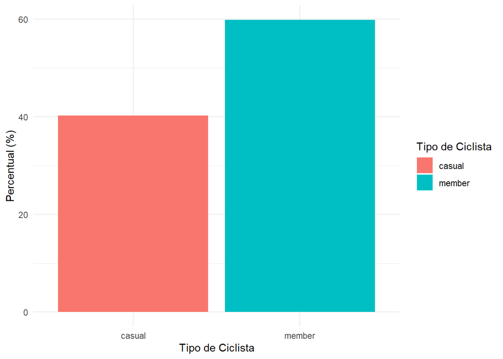

```r
# Crie uma tabela de frequência da coluna "member_casual"
frequencia <- table(cyclist2022v4$member_casual)

# Calcule os percentuais
percentuais <- prop.table(frequencia) * 100

# Crie um dataframe com os resultados
dados_grafico <- data.frame(member_casual = names(frequencia),
                            percentual = percentuais)

# Crie o gráfico de barras usando o ggplot2
ggplot(dados_grafico, aes(x = member_casual, y = percentuais, fill = member_casual)) +
  geom_bar(stat = "identity", position = "dodge") +
  labs(x = "Tipo de Ciclista", y = "Percentual (%)") +
  theme_minimal() +
  guides(fill = guide_legend(title = "Tipo de Ciclista"))
```

```r
contagem <- table(cyclist2022v4$member_casual)
print(contagem)
```

```
##
##  casual  member
## 1716281 2553822
```

### Analisando a Media do tempo_total_min para cada tipo de membro por dia da semana:

```r
media_membro_dia_semana <- aggregate(tempo_total_min ~ dia_semana + member_casual, data = cyclist2022v4, FUN = mean)
```

### Gráfico de barras - “Media da duração do Passeio X Dia da Semana e Tipo de usuário”:

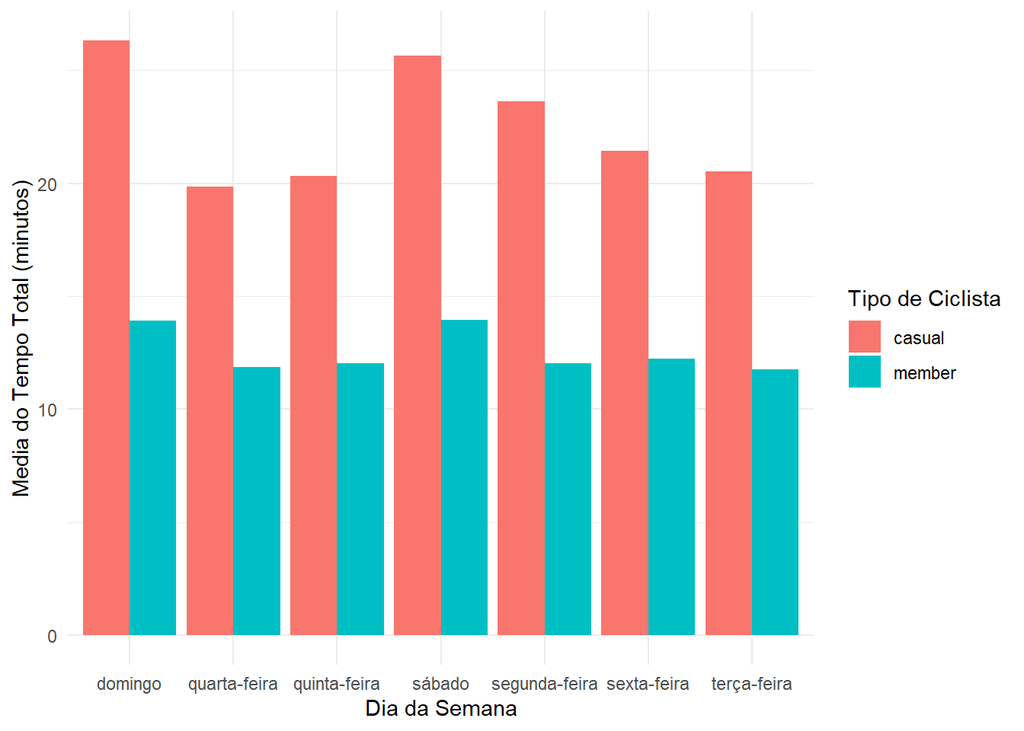

```r
ggplot(media_membro_dia_semana, aes(x = dia_semana, y = tempo_total_min, fill = member_casual)) +
  geom_bar(stat = "identity", position = "dodge") +
  labs(x = "Dia da Semana", y = "Media do Tempo Total (minutos)", fill = "Tipo de Ciclista") +
  theme_minimal()
```

```r
media_tempo_por_usuario <- cyclist2022v4 %>%
  group_by(member_casual) %>%
  summarise(media_tempo = mean(tempo_total_min))

print(media_tempo_por_usuario)
```

```
## # A tibble: 2 × 2
##   member_casual media_tempo
##   <chr>               <dbl>
## 1 casual               23.0
## 2 member               12.5
```

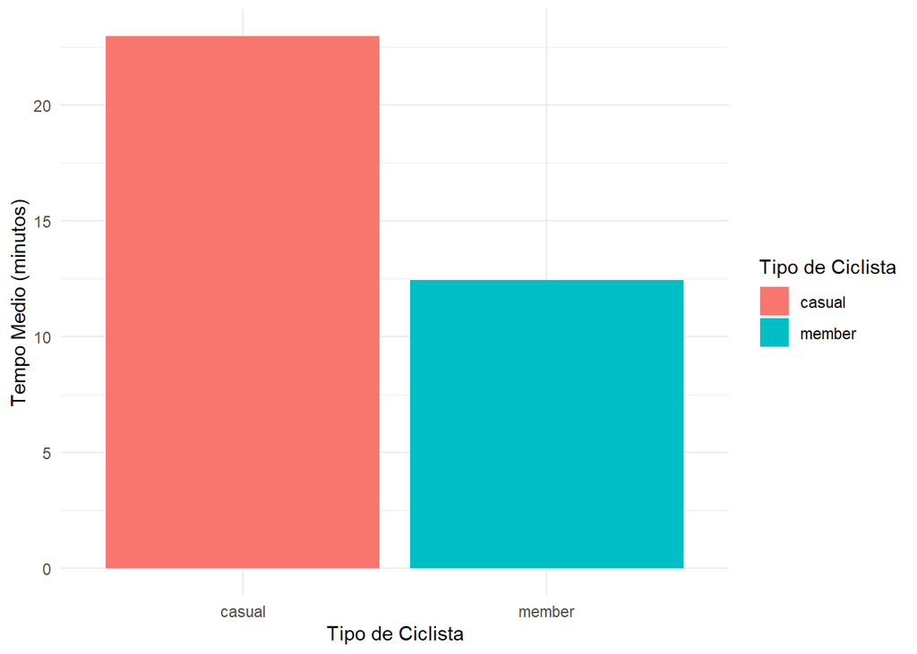

```r
media_tempo_por_usuario_min <- aggregate(tempo_total_min ~ member_casual, data = cyclist2022v4, FUN = mean)

ggplot(media_tempo_por_usuario_min, aes(x = member_casual, y = tempo_total_min, fill = member_casual)) +
  geom_bar(stat = "identity", position = "dodge") +
  labs(x = "Tipo de Ciclista", y = "Tempo Medio (minutos)") +
  theme_minimal() +
  guides(fill = guide_legend(title = "Tipo de Ciclista"))
```

### Gráfico de barras “Media de Quilômetros percorridos X tipo de usuário”

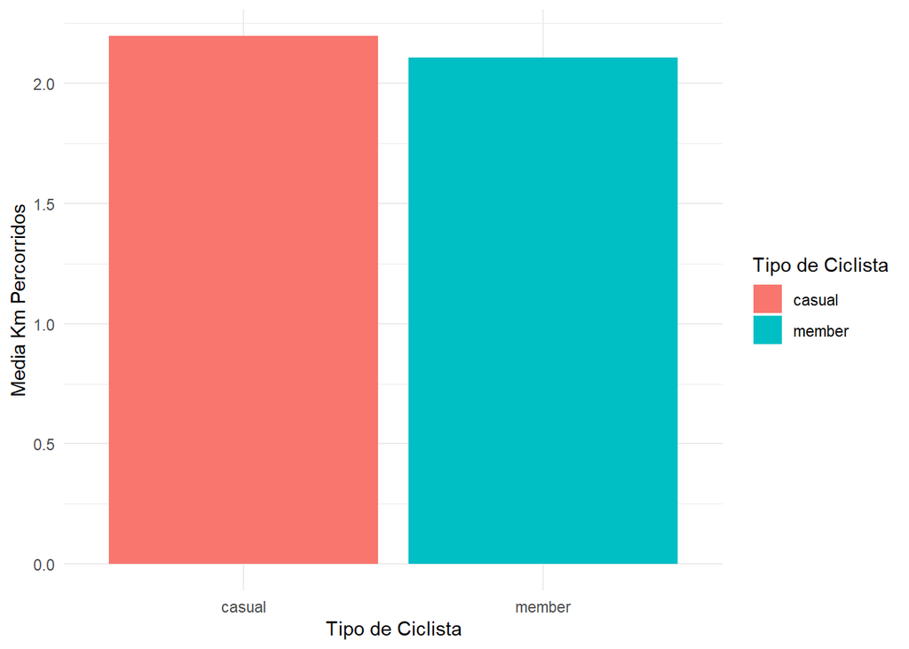

```r
# Calcula a média dos quilômetros percorridos por tipo de usuário
media_km_por_usuario <- aggregate(cyclist2022v4$KM_percorridos, by = list(member_casual = cyclist2022v4$member_casual), FUN = mean)

# Cria o gráfico de barras
ggplot(media_km_por_usuario, aes(x = member_casual, y = x, fill = member_casual)) +
  geom_bar(stat = "identity", position = "dodge") +
  labs(x = "Tipo de Ciclista", y = "Media Km Percorridos", fill = "Tipo de Ciclista") +
  theme_minimal()
```

```r
  guides(fill = guide_legend(title = "Tipo de Ciclista"))
```

[output not shown]

[output cut: 14 more lines]

[output not shown]

### Analisando a demanda em cada estação do ano por tipo usuário:

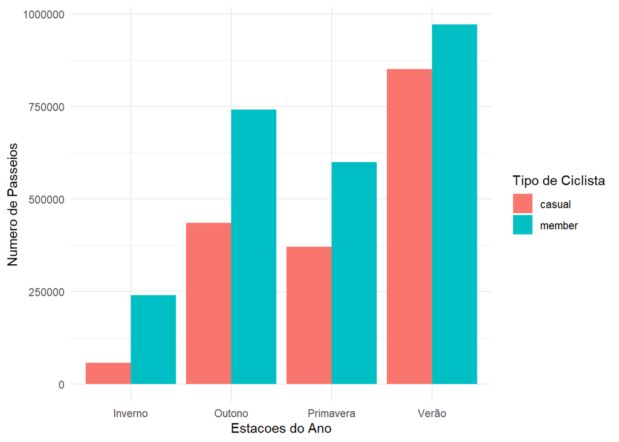

```r
ggplot(cyclist2022v4, aes(x = estacao, fill = member_casual)) +
  geom_bar(position = "dodge") +
  labs(x = "Estacoes do Ano", y = "Numero de Passeios", fill = "Tipo de Ciclista") +
  theme_minimal()
```

### Analisando a demanda mensal por tipo de usuário:

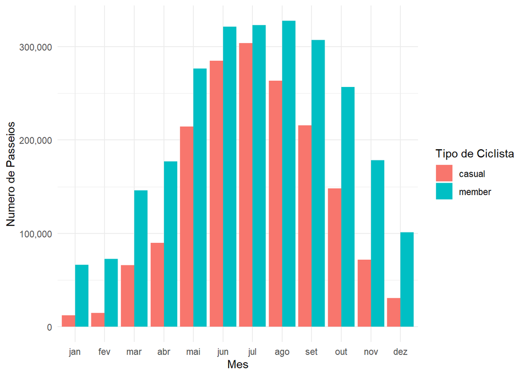

```r
ggplot(cyclist2022v4, aes(x = mes, fill = member_casual)) +
  geom_bar(position = "dodge") +
  labs(x = "Mes", y = "Numero de Passeios", fill = "Tipo de Ciclista") +
  scale_y_continuous(labels = scales::comma) +
  theme_minimal()
```

```r
contagem <- cyclist2022v4 %>%
  group_by(mes, member_casual) %>%
  summarise(contagem = n())
```

[output not shown]

```r
print(contagem)
```

```
## # A tibble: 24 × 3
## # Groups:   mes [12]
##    mes   member_casual contagem
##    <ord> <chr>            <int>
##  1 jan   casual           12389
##  2 jan   member           66470
##  3 fev   casual           14870
##  4 fev   member           72545
##  5 mar   casual           65987
##  6 mar   member          146196
##  7 abr   casual           89984
##  8 abr   member          177248
##  9 mai   casual          214559
## 10 mai   member          276261
## # ℹ 14 more rows
```

### Analisando a Demanda por dia da semana:

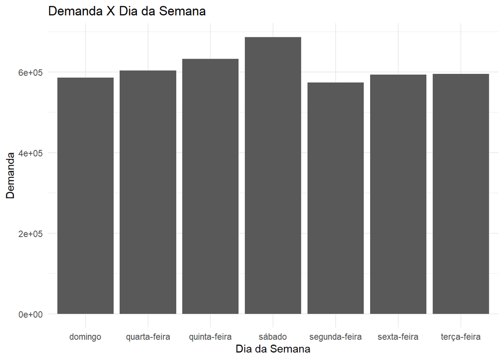

```r
ggplot(cyclist2022v4, aes(x = dia_semana)) +
  geom_bar(position = "dodge") +
  labs(x = "Dia da Semana", y = "Demanda") +
  ggtitle("Demanda X Dia da Semana") +
  theme_minimal()
```

### Analisando a Demanda por tipo de usuário e dia da semana:

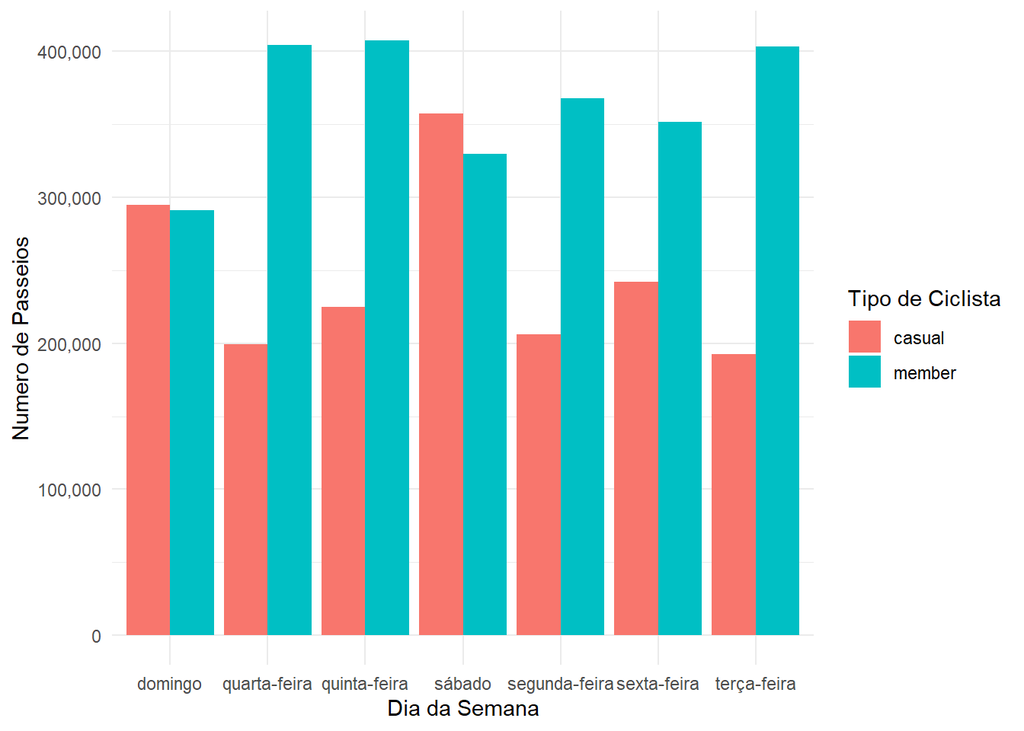

```r
ggplot(cyclist2022v4, aes(x = dia_semana, fill = member_casual)) +
  geom_bar(position = "dodge") +
  labs(x = "Dia da Semana", y = "Numero de Passeios", fill = "Tipo de Ciclista") +
  scale_y_continuous(labels = scales::comma) +
  theme_minimal()
```

```r
contagem_dias_usuario <- cyclist2022v4 %>%
  count(dia_semana, member_casual) %>%
  spread(member_casual, n, fill = 0)

print(contagem_dias_usuario)
```

```
##      dia_semana casual member
## 1       domingo 294706 290903
## 2  quarta-feira 199209 404270
## 3  quinta-feira 224911 407093
## 4        sábado 357086 329400
## 5 segunda-feira 206264 367561
## 6   sexta-feira 241881 351513
## 7   terça-feira 192224 403082
```

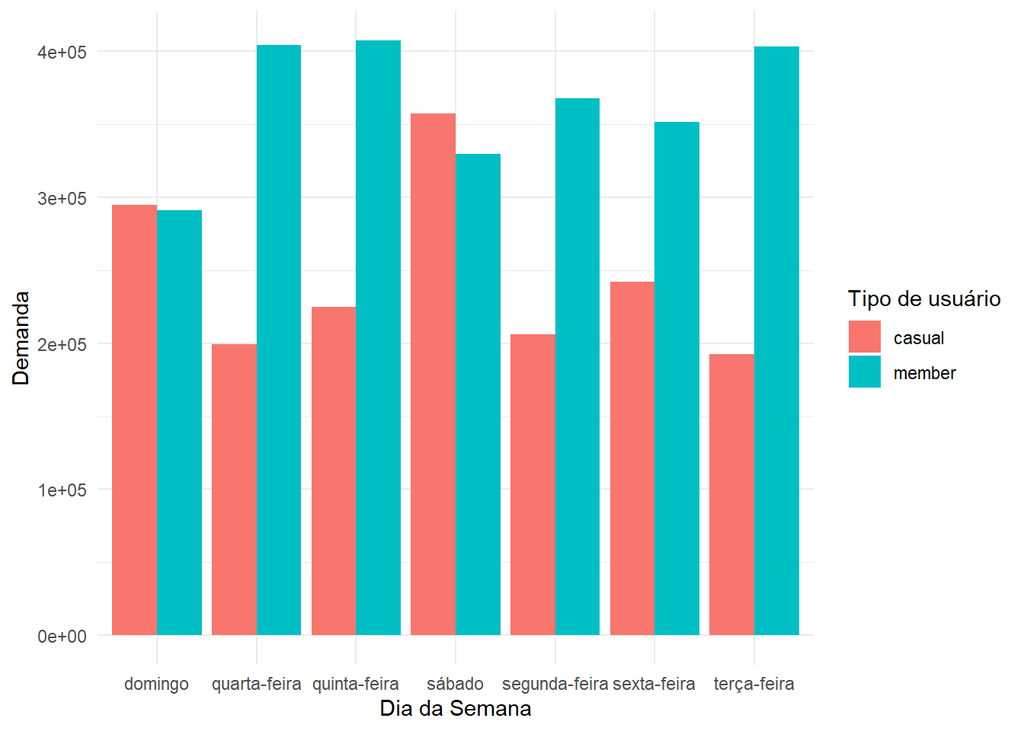

```r
ggplot(cyclist2022v4, aes(x = dia_semana, fill = member_casual)) +
  geom_bar(position = "dodge") +
  labs(x = "Dia da Semana", y = "Demanda", fill = "Tipo de usuário") +
    theme_minimal()
```

### Analisando o horário mais demandado:

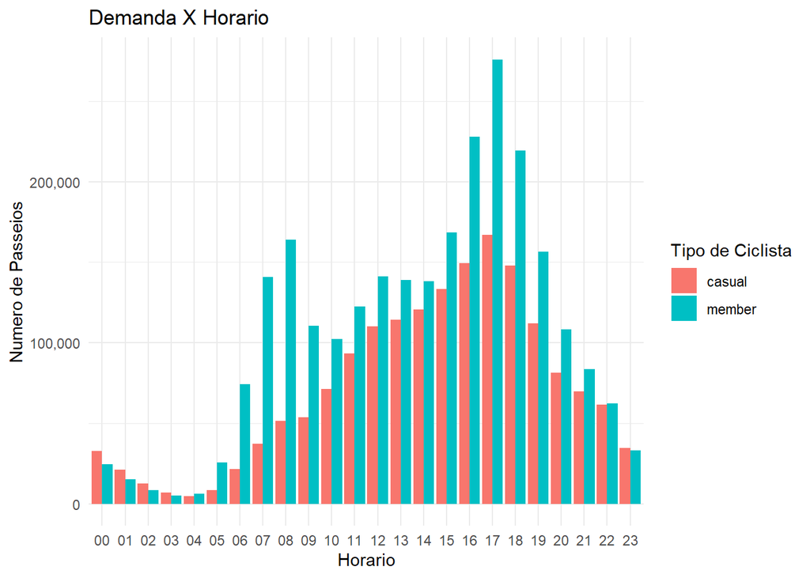

```r
ggplot(cyclist2022v4, aes(x = hora, fill = member_casual)) +
  geom_bar(position = "dodge") +
  labs(x = "Horario", y = "Numero de Passeios", fill = "Tipo de Ciclista") +
  scale_y_continuous(labels = scales::comma) +
  ggtitle("Demanda X Horario") +
  theme_minimal()
```

### Analisando o tipo de bicicleta mais usada:

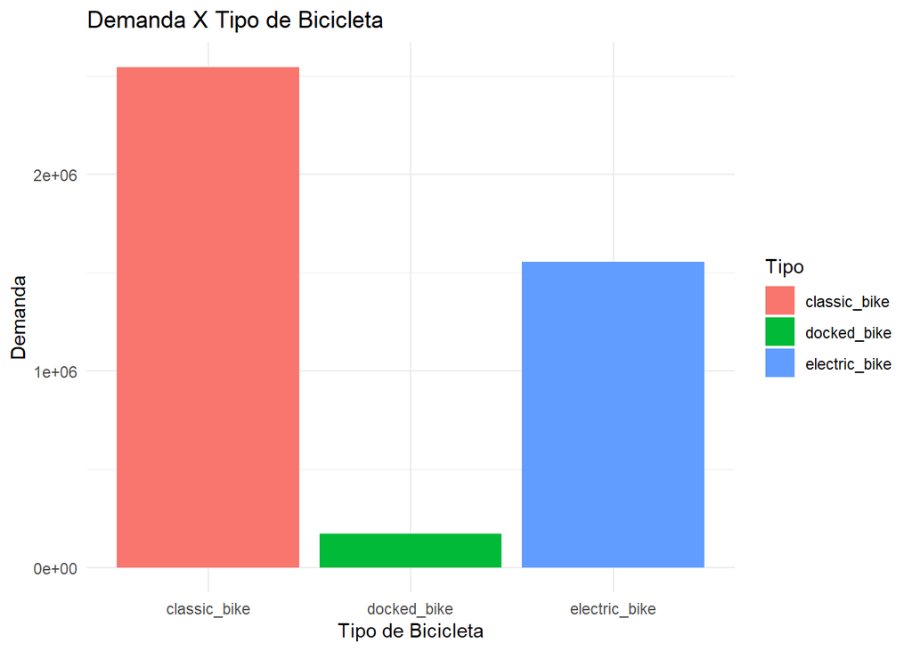

```r
ggplot(cyclist2022v4, aes(x = rideable_type, fill = rideable_type)) +
  geom_bar(position = "dodge") +
  labs(x = "Tipo de Bicicleta", y = "Demanda", fill = "Tipo") +
  ggtitle("Demanda X Tipo de Bicicleta") +
  theme_minimal()
```